# Algorithms for Machine Learning

In this notebook file, I will be writing two foundational machine learning algorithms: linear regression and logistic regression. For each algorithm, I will be writing several methods for the code, and try to fit some data set to my algorithms. These are fairly basic examples as this is my first ever ML experience. I will be only using the base ML algorithms without regularization or too much data manipulation. I will soon revisit this topic to update and fine tune my algorithms.

```python
import numpy as np
import matplotlib.pyplot as plt
```

## Section 1: single feature linear regression

```python
#this section establishes the method used for the linear regression algorithm.

#lin_output: this method calculates the y_bar based on a linear formula
#   Input: w and b are the constants for fitting the regression. X is the input of features. (1 dimensional vector for now)
def lin_output(w, b, X):
    return w*X + b

#cost_funct: this function calculates the cost of the current fit.
#    Input: same rules as the lin_output function. Y is the matching value to data in X.
def cost_func(w, b, X, Y):
    size = len(X)
    total_cost = 0
    y_bar = lin_output(w,b, X)

    for i in range(size):
        total_cost += (Y[i]- y_bar[i])**2

    total_cost = total_cost / (2*size)
    return total_cost

#calc_gradient: this function calculate the gradient to current variables.
def calc_gradient(w, b, X, Y):
    size = X.shape[0]
    dj_dw = 0
    dj_db = 0

    for i in range(size):
        f_wb = w * X[i] + b
        dj_db += (f_wb - Y[i])
        dj_dw += (X[i]*(f_wb - Y[i]))

    dj_dw = dj_dw / size
    dj_db = dj_db / size


    return dj_dw, dj_db

def gradient_descent(w_in, b_in, X, Y, alpha, num_iters, gradient_function):
    w = w_in
    b = b_in #avoid changes to the original parameters. Cautionary step for future upgrades.

    for i in range(num_iters):
        dj_dw, dj_db = gradient_function(w, b, X, Y)

        #update parameters for descent
        w = w - alpha * dj_dw
        b = b - alpha * dj_db

    return w, b,
```

```python
test_vector_1 = np.array([1,2,3,4,5,10,20])
test_y_1 = np.array([12,25,34,45,52,107,210])
```

```python
print(cost_func(10,3, test_vector_1, test_y_1))
```

```
5.428571428571429
```

```python
w_init = 0
b_init = 0

iteration = 10000
alpha_1 = 1.0e-2

w_final, b_final = gradient_descent(w_init, b_init, test_vector_1, test_y_1, alpha_1, iteration, calc_gradient)
```

```python
print(f"The w of the best fit line is {w_final}")
print(f"The b of the best fit line is {b_final}")
```

```
The w of the best fit line is 10.372580645161296
The b of the best fit line is 2.604838709677365
```

Now this seems to be working, Let's find a real data set to test this out. I found a simple dataset with US state poverty rate and teen pregnancy rate. source: https://online.stat.psu.edu/stat462/node/101/

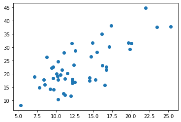

```python
with open('data.txt') as f:
    lines = f.readlines()

dataset = []
poverty_rate = []
teen_birth_rate = []
for line in lines[1:]:
    if line != 0:
        tmp = line.split("\t")
        poverty_rate.append(float(tmp[1]))
        teen_birth_rate.append(float(tmp[2]))
    else:
        continue

fig, ax = plt.subplots()
ax.scatter(poverty_rate, teen_birth_rate)
plt.show()
```

```python
w_init = 0
b_init = 0

iteration = 10000
alpha_1 = 1.0e-2

w_final, b_final = gradient_descent(w_init, b_init, np.array(poverty_rate), np.array(teen_birth_rate), alpha_1, iteration, calc_gradient)
```

```python
print(f"The w of the best fit line is {w_final}")
print(f"The b of the best fit line is {b_final}")
```

```
The w of the best fit line is 1.3733691359061466
The b of the best fit line is 4.266949035022754
```

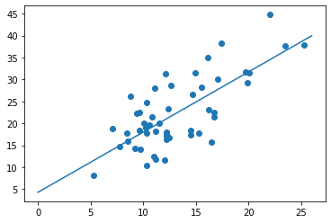

```python
#making data for a best fit line
x = []
y = []

for i in range(27):
    x.append(i)
    y.append(w_final*i + b_final)

fig, ax = plt.subplots()
ax.scatter(poverty_rate, teen_birth_rate)
ax.plot(x,y)

plt.show()
```

This looks ok for this data set. The regression posted by data source page is y = 4.267 + 1.373*x, so we are exactly on the dot.

## Section 2: A logistic regression machine learning algorithm

```python
def sigmoid(z):
    sigmoid_out = 1/(1+ np.exp(-z))
    return sigmoid_out

#logi_cost: calculate cost of the logistic growth function.
#          input: these x, y , w, b are coded as scalars. upper level function needs to consider this.
def logi_cost(x, y, w, b, sigmoid):
    fw_b = w*x + b
    cost = -y*np.log(sigmoid(fw_b))-(1-y)*np.log(1-sigmoid(fw_b))
    return cost
#compute_gradient: calculate gradient at the current point
#                input: X, Y are vectors. w, b are still single scalars here.
def compute_gradient(X, Y, w, b):
    size = len(X)
    dj_dw = 0
    dj_db = 0

    for i in range(size):
        z_wb = w*X[i] + b
        f_wb = sigmoid(z_wb)
        dj_db_i = f_wb - Y[i]
        dj_db += dj_db_i

        dj_dw_i = (f_wb - Y[i])*X[i]
        dj_dw += dj_dw_i

    dj_dw = dj_dw/size
    dj_db = dj_db/size

    return dj_dw, dj_db

def logi_gradient_descent(X, Y, w, b, iteration, alpha):
    w_copy = w
    b_copy = b
    for i in range(iteration):
        dj_dw, dj_db = compute_gradient(X,Y,w_copy,b_copy)
        w_copy = w_copy - alpha* dj_dw
        b_copy = b_copy - alpha * dj_db

    return w_copy, b_copy
```

```python
X = [1,1,1,1.4, 2, 11, 13, 11, 10, 12, 15]
Y = [0,0,0,0,0,1,1,1,1,1,1]
```

```python
w_init = 10
b_init = 10

iteration = 1000000
alpha_1 = 1.0e-3

w_final, b_final = logi_gradient_descent(X, Y, w_init, b_init, iteration, alpha_1)
```

```python
print(f"The w of the best fit line is {w_final}")
print(f"The b of the best fit line is {b_final}")
```

```
The w of the best fit line is 1.387994732903034
The b of the best fit line is -7.573980745741937
```

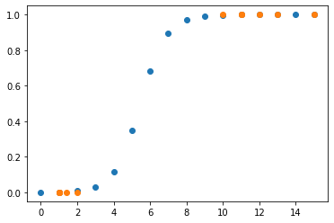

```python
x = []
y = []

for i in range(0,16):
    x.append(i)
    fw_b = w_final*i + b_final
    y.append(sigmoid(fw_b))

fig, ax = plt.subplots()
ax.scatter(x, y)
ax.scatter(X,Y)


plt.show()
```

Now we can see that this also works ok for the small constructed data set. The blue is the constructed regression line and the orange is the initial data set.

## Section 3: regressions with multiple features.

This section will explore some regression with more than 1 features. This will only require some modification of the previous algorithms. More specifically, we need to consider the dimensions of the input and add in extra for loops for the gradient method. I will now do this to the logistic regression model algorithms as it is easier to visualize the data.

```python
#this method should automatically accept a variety of input due to numpy method.
def sigmoid(z):
    sigmoid_out = 1/(1+ np.exp(-z))
    return sigmoid_out

#compute_gradient: calculate gradient at the current point
#                input: X is a matrix of vector. Y, W is a column vector. b is a scalar.
def compute_gradient(X, Y, W, b):
    m, n = X.shape
    dj_dw = np.zeros(W.shape)
    dj_db = 0

    for i in range(m):#go through rows
        z_wb = 0
        for j in range(n):#go through columns(multiply different features)
            z_wb += W[j]*X[i][j]

        z_wb += b
        f_wb = sigmoid(z_wb)

        dj_db_i = f_wb - Y[i]
        dj_db += dj_db_i

        for j in range(n):
            dj_dw[j] = (f_wb - Y[i])*X[i][j]

    dj_dw = dj_dw/m
    dj_db = dj_db/m

    return dj_dw, dj_db

#same as before. Gradient descent is exactly the same method here.
def logi_gradient_descent(X, Y, W, b, iteration, alpha):
    w_copy = W.copy()
    b_copy = b
    for i in range(iteration):
        dj_dw, dj_db = compute_gradient(X,Y,w_copy,b_copy)
        w_copy = w_copy - alpha* dj_dw
        b_copy = b_copy - alpha * dj_db

    return w_copy, b_copy
```

This algorithm should suffice as a basic ML logistic regression model. There is a dataset from Kaggle.com that features some of the data from the titanic survivors. I shall use the data set to explore what I can do with this simple algorithm.

```python
import pandas as pd
```

```python
train = pd.read_csv('train.csv')
gender = pd.read_csv('gender_submission.csv')
train
```

|  | PassengerId | Survived | Pclass | Name | Sex | Age | SibSp | Parch | Ticket | Fare | Cabin | Embarked |
| --- | --- | --- | --- | --- | --- | --- | --- | --- | --- | --- | --- | --- |
| 0 | 1 | 0 | 3 | Braund, Mr. Owen Harris | male | 22.0 | 1 | 0 | A/5 21171 | 7.2500 | NaN | S |
| 1 | 2 | 1 | 1 | Cumings, Mrs. John Bradley (Florence Briggs Th... | female | 38.0 | 1 | 0 | PC 17599 | 71.2833 | C85 | C |
| 2 | 3 | 1 | 3 | Heikkinen, Miss. Laina | female | 26.0 | 0 | 0 | STON/O2. 3101282 | 7.9250 | NaN | S |
| 3 | 4 | 1 | 1 | Futrelle, Mrs. Jacques Heath (Lily May Peel) | female | 35.0 | 1 | 0 | 113803 | 53.1000 | C123 | S |
| 4 | 5 | 0 | 3 | Allen, Mr. William Henry | male | 35.0 | 0 | 0 | 373450 | 8.0500 | NaN | S |
| ... | ... | ... | ... | ... | ... | ... | ... | ... | ... | ... | ... | ... |
| 886 | 887 | 0 | 2 | Montvila, Rev. Juozas | male | 27.0 | 0 | 0 | 211536 | 13.0000 | NaN | S |
| 887 | 888 | 1 | 1 | Graham, Miss. Margaret Edith | female | 19.0 | 0 | 0 | 112053 | 30.0000 | B42 | S |
| 888 | 889 | 0 | 3 | Johnston, Miss. Catherine Helen "Carrie" | female | NaN | 1 | 2 | W./C. 6607 | 23.4500 | NaN | S |
| 889 | 890 | 1 | 1 | Behr, Mr. Karl Howell | male | 26.0 | 0 | 0 | 111369 | 30.0000 | C148 | C |
| 890 | 891 | 0 | 3 | Dooley, Mr. Patrick | male | 32.0 | 0 | 0 | 370376 | 7.7500 | NaN | Q |

891 rows × 12 columns

There is a lot of irrelevant data here, and we need to choose several features to base on model on. Based on historical knowledge, priorites were given to the youth and woman during evacuation, so these were definitely selected. At the same time, ticket class will also greatly impact one's chance for survival as the rich were also prioritized. Thus, I wil use age, gender, and ticket class as the three features to train my model.

First, we need to clean up our data.

```python
df = train[['PassengerId','Pclass','Age','Sex','Survived']]
```

```python
df['Sex'].mask(df['Sex'] == 'male', 0, inplace = True)
df['Sex'].mask(df['Sex'] == 'female', 1, inplace = True)

df.dropna(inplace = True)
df.reset_index(drop = "true")
```

|  | PassengerId | Pclass | Age | Sex | Survived |
| --- | --- | --- | --- | --- | --- |
| 0 | 1 | 3 | 22.0 | 0 | 0 |
| 1 | 2 | 1 | 38.0 | 1 | 1 |
| 2 | 3 | 3 | 26.0 | 1 | 1 |
| 3 | 4 | 1 | 35.0 | 1 | 1 |
| 4 | 5 | 3 | 35.0 | 0 | 0 |
| ... | ... | ... | ... | ... | ... |
| 709 | 886 | 3 | 39.0 | 1 | 0 |
| 710 | 887 | 2 | 27.0 | 0 | 0 |
| 711 | 888 | 1 | 19.0 | 1 | 1 |
| 712 | 890 | 1 | 26.0 | 0 | 1 |
| 713 | 891 | 3 | 32.0 | 0 | 0 |

714 rows × 5 columns

```python
# the input data is figured out here. We can find out the identity of the passenger with the row index and df look up.
train_matrix = np.array(df[['Pclass','Age','Sex']])

#survival result is here
survival = np.array(df['Survived'])
```

```python
w_init = np.array([10,10,10])#arbituary numbers
b_init = 10

iteration = 100000
alpha_1 = 1.0e-2

w_final, b_final = logi_gradient_descent(train_matrix, survival, w_init, b_init, iteration, alpha_1)
```

```python
print(f"The w matrix contains  {w_final}")
print(f"The b constant is {b_final}")
```

[output not shown]

```python
#I am just feeding back the same data into the system to see how many is predicted to be alive based on our model.
fw_b = np.dot(train_matrix,w_final) + b_final
results = []
for i in fw_b:
    prob =  1/(1+ np.exp(-i))
    if prob > 0.7:
        results.append(1)
    else:
        results.append(0)
```

```python
ind = 0
correct = 0
for i in df['Survived'].values:
    if i == results[ind]:
        correct += 1
    ind += 1

print(f"Correct prediction percentage is {correct/len(results)}")
```

[output not shown]

Despite its current shortcomings, this practice is really valuable as it is my first ever ML experience. I will be keeping this as a record of my progress, and using this as the foundation of my ML work. I will soon come back to this data set and improve on the algorithm further.

There are several things that I will need to consider:

1. Is logistic regression the best fit here? The course taught by Andrew Ng indicates that most modern ML networks replaces sigmoid function with ReLu function.
2. I will need to look at more features as well. I need to develop prediction tools for passeners with missing information as well.
3. Adapting this work with a neural network could be interesting practice as well.
4. Lastly, I want to figure out a faster way to run this code. I am unsure whether this current iteration utilizes parallel processing or not, but the CPU load suggests that I was running everything on a single core.